# Regresión logística con R - Vehiculos Familiares

Primero leemos los datos:

```r
#Cargamos el dataset
carros.dataset = read.csv("pricevshp.csv")
# Asignamos los nombres de las columnas
colnames(carros.dataset) <- c("Nombre","CaballosFuerza","Precio","Familiar")
carros.dataset
```

| Nombre | CaballosFuerza | Precio | Familiar |
| --- | --- | --- | --- |
| Merc 240D | 62 | 11900 | 1 |
| Ford Festiva 4 | 63 | 6319 | 1 |
| Toyota Corolla | 65 | 17872 | 1 |
| Fiat 128 | 66 | 3470 | 1 |
| Fiat X1-9 | 66 | 9640 | 1 |
| Subaru Justy 3 | 73 | 5866 | 1 |
| Pontiac LeMans 4 | 74 | 7254 | 1 |
| Toyota Tercel 4 | 78 | 6488 | 1 |
| Mercury Tracer 4 | 82 | 8672 | 1 |
| Ford Escort 4 | 90 | 7402 | 1 |

[output cut: 78 more lines]

Una representación gráfica de los datos, puede obtenerse mediante:

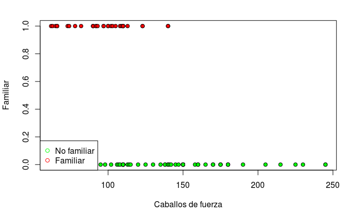

```r
colores <- NULL
colores[carros.dataset$Familiar==0] <- 'green' #No familiar
colores[carros.dataset$Familiar==1] <- 'red' #Familiar
plot(carros.dataset$CaballosFuerza, carros.dataset$Familiar, pch = 21, bg = colores, xlab = 'Caballos de fuerza', ylab = 'Familiar')
legend('bottomleft', c('No familiar', 'Familiar'), pch = 21, col = c('green', 'red'))
```

Hemos usado los argumentos pch y bg para mejorar la apariencia del gráfico. También hemos usado el comando legend para incluir una leyenda explicativa.

Parece razonable, a la vista de los datos, pensar que los caballos de fuerza puede influir en la probabilidad de que un carro sea familiar o no. En esta práctica, vamos a ajustar un modelo de regresión logística para estudiar la posible relación. Para ajustar el modelo se usa el comando glm (para modelos lineales generalizados) indicando que la respuesta es binomial mediante el argumento family:

```r
reg <- glm(Familiar ~ CaballosFuerza, data = carros.dataset, family=binomial)
summary(reg)
```

```
Call:
glm(formula = Familiar ~ CaballosFuerza, family = binomial, data = carros.dataset)

Deviance Residuals:
    Min       1Q   Median       3Q      Max
-1.7942  -0.4582  -0.1144   0.6454   2.2111

Coefficients:
               Estimate Std. Error z value Pr(>|z|)
(Intercept)     8.33267    1.98536   4.197 2.70e-05 ***
CaballosFuerza -0.07633    0.01786  -4.273 1.93e-05 ***
---
Signif. codes:  0 ‘***’ 0.001 ‘**’ 0.01 ‘*’ 0.05 ‘.’ 0.1 ‘ ’ 1

(Dispersion parameter for binomial family taken to be 1)

    Null deviance: 116.435  on 87  degrees of freedom
Residual deviance:  66.591  on 86  degrees of freedom
AIC: 70.591

Number of Fisher Scoring iterations: 6
```

En el modelo de regresión logística la raíz de las desviaciones representa el papel de los residuos:

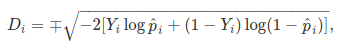

Para representar gráficamente la función logística estimada, calculamos las probabilidades estimadas de ser un carro familiar o no (usando el comando predict) para un vector adecuado de nuevos valores de caballos de fuerza (entre 60 hp y 250 hp):

```r
datos <- data.frame(CaballosFuerza = seq(60, 250, 10))
probabilidades <- predict(reg, datos, type = 'response')  # por defecto calcularía log p_i/(1-p_i), para calcular p_i usamos el argumento type
plot(carros.dataset$CaballosFuerza, carros.dataset$Familiar, pch = 21, bg = colores, xlab = 'Caballos de Fuerza', ylab = 'Familiar')
legend('bottomleft', c('No Familiar', 'Familiar'), pch = 21, col = c('green', 'red'))
```

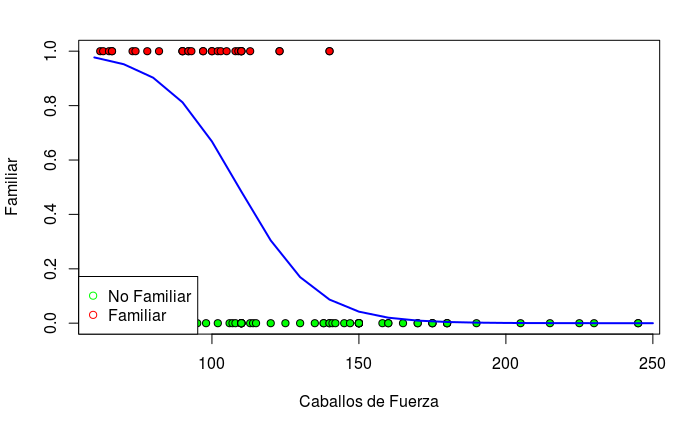

```r
lines(datos$CaballosFuerza, probabilidades, col = 'blue', lwd = 2)
```